# Explaining Poisson regression

Adam Howes

Abstract

**Background** Detecting exponential growth is a central goal of the Nucleic Acid Observatory (NAO). Regression using a Poisson generalised linear model (GLM) is possibly the simplest statistical approach to detecting exponential growth.

**Task** In this notebook, we aim to explain what Poisson regression is and why it might be suitable as an exponential growth detection method.

**Next steps** This notebook could be extended by describing the statistical properties and computational requirements of Poisson regression in further depth.

```r
knitr::opts_chunk$set(
  echo = TRUE,
  cache = TRUE,
  autodep = TRUE,
  cache.comments = FALSE
)

options(scipen = 999)

cbpalette <- multi.utils::cbpalette()
```

```r
library(tidyverse)
library(cowplot)
library(patchwork)
theme_set(theme_minimal())
```

## Background

### What is the Poisson distribution

The Poisson distribution is a discrete probability distribution for the number of events occurring in a fixed interval e.g. of time or space. It makes two key assumptions: (1) events occur at a constant rate, and (2) events occur independently. If $y$ follows a Poisson distribution with constant rate $\lambda$ then we write
$$y \sim \text{Pois}(\lambda).$$

Why might this distribution be relevant to the NAO? The Poisson distribution is a reasonable first guess for the variation in how often we see a particular $k$-mer. For example, suppose $\lambda = 10$ copies per day. That means we expect to see on average 10 copies in any given day, but naturally there will be some variation. It might be reasonable to describe that variation, to a first approximation, with a Poisson distribution[^1]

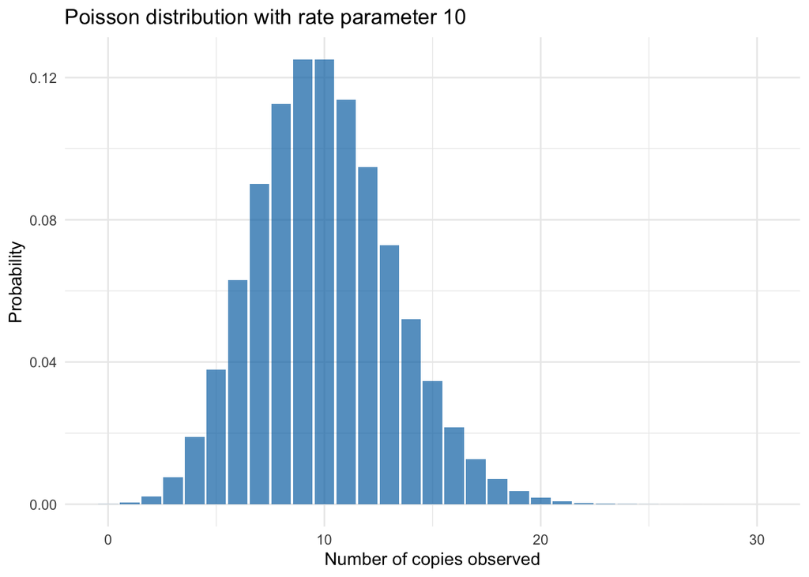

```r
data.frame(x = 0:30) %>%
  mutate(y = dpois(x, lambda = 10)) %>%
  ggplot(aes(x = x, y = y)) +
    geom_col(fill = cbpalette[5], alpha = 0.7) +
    theme_minimal() +
    labs(
      x = "Number of copies observed", y = "Probability",
      title = "Poisson distribution with rate parameter 10"
    )
```

The NAO will not just observe k-mers on one day, but on many consecutive days. We represent the number of $k$-mers observed on day $t$ as $y_t$. For example, over a 14 day period we might collect the data
$$(y_1 , y_2, y_3, y_4, \ldots, y_{13}, y_{14}).$$

Data where the index (here $1, \ldots, 14$) refers to time points are known as “time-series”. At each time $t$ we could assume that the data follows a Poisson distribution with daily rate $\lambda_t$
$$y_t \sim \text{Pois}(\lambda_t).$$
Suppose that the rate doesn’t change by day, and $\lambda_t = 10$ for all days. We can simulate a draw from this time-series as follows, where the dashed line is the expected number of copies observed (10):

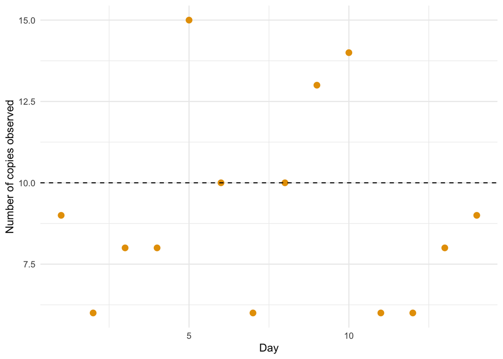

```r
df <- data.frame(t = 1:14) %>%
  mutate(y = rpois(t, lambda = 10))

ggplot(df, aes(x = t, y = y)) +
  geom_point(col = cbpalette[3], size = 2.5) +
  theme_minimal() +
  geom_hline(yintercept = 10, linetype = "dashed") +
  labs(x = "Day", y = "Number of copies observed")
```

Each data point is a draw from the Poisson distribution with rate parameter 10 described above. While this data happens to have a constant rate, there is no reason that has to be the case. When we see some new time-series data, we would like to learn the values of $\lambda_t$ which generated it. This can be done using Poisson regression! And, if you’re thinking ahead, then learning that the underlying values of $\lambda_t$ follow an exponential growth pattern (unlike the underlying values here which are constant) is exactly what’s required to classify a time-series as growing exponentially.

### What is Poisson regression

Poisson regression is similar to [linear regression](https://en.wikipedia.org/wiki/Linear_regression) where you essentially fit a straight line through the data.

There are two key differences.

1. Linear regression assumes Gaussian errors, and we want Poisson errors instead. Gaussian errors are not suitable for count data as they are continuous rather than discrete.
2. In Poisson regression we want to infer a rate parameter. Rate parameters must be greater than zero $\lambda_t > 0$ (try to think about what it would mean for a rate to be negative) so we can’t just use a linear equation of the form
   $$\lambda_t= \beta_0 + \beta_1 x_{1t} + \cdots + \beta_{p}x_{pt} =
   \beta^\top x$$
   as we would in a linear regression. This is because there is nothing in the above equation which guarantees that $\lambda_t > 0$.

How can you guarantee that, no matter the value of $\beta^\top x$ on the right hand side, the rate parameter is positive? One solution is to use an inverse link function $g^{-1}: \mathbb{R} \to \mathbb{R}^{+}$ which maps from the real numbers to the positive numbers
$$\lambda_t = g^{-1}(\beta^\top x).$$
Models like this where we use a link function are called generalised linear models (GLMs). In Poisson regression, we use the exponential function as a link
$$\lambda_t = \exp(\beta^\top x).$$
The Poisson regression model is then fully expressed as follows
$$y_t \sim \text{Pois}(\lambda_t), \\
\log(\lambda_t) = \beta^\top x.$$

### Why might this approach work to detect exponential growth

Suppose that we think that our underlying Poisson rate is exponentially increasing. We could choose to use a model which includes an intercept $\beta_0$ and one covariate $x$ which represents the time $t$
$$\log(\lambda_t) = \beta_0 + \beta t$$

If we fit this model to data, and find that a point estimate for the $\beta$ parameter is $\hat \beta = 1$ then this would correspond to an underlying Poisson rate $\lambda_t$ which increases exponentially, exactly what we would like to detect! So, a simple method for detecting exponential growth is to **fit this Poisson regression model then look at the inference for the slope parameter $\beta$ and assess if it is sufficiently above zero.**

Let’s try it with the data we generated above. Poisson GLM models are easy to fit in R, only requiring the following code:

```r
fit <- glm(y ~ 1 + t, family = "poisson", data = df)
fit
```

```
##
## Call:  glm(formula = y ~ 1 + t, family = "poisson", data = df)
##
## Coefficients:
## (Intercept)            t
##   2.2165768   -0.0004808
##
## Degrees of Freedom: 13 Total (i.e. Null);  12 Residual
## Null Deviance:       12.32
## Residual Deviance: 12.32     AIC: 72.65
```

[^1]: In reality, you might be thinking that $k$-mers do not arise independently (and I think you’d be right!). That’s something we might want to think about attending to eventually.